dgtrabada

# Cuestionario particiones

## Particiones (I)

En los apartados (I) y (II), las preguntas se refieren a discos con tabla de particiones **msdos (MBR)**. Las de GPT están en el apartado (III).

1. **Ejercicio 01**: con GParted crea una tabla de particiones msdos y en ella las siguientes particiones primarias.

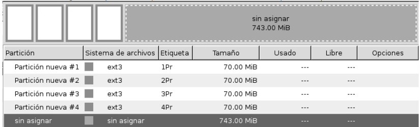

Intenta hacer otra partición que sea primaria, lógica y extendida. Completa las siguientes frases:

1. Si en un disco duro con 4 particiones primarias creamos una partición primaria más obtenemos que...

Sí podemos crearla No podemos crearla

2. Si en un disco duro con 4 particiones primarias creamos una partición lógica más obtenemos que...

Sí podemos crearla No podemos crearla

3. Si en un disco duro con 4 particiones primarias creamos una partición extendida más obtenemos que...

Sí podemos crearla No podemos crearla

2. **Ejercicio 02**: realiza las siguientes particiones, 2 primarias y 1 extendida (utiliza ~7% del disco para cada una).

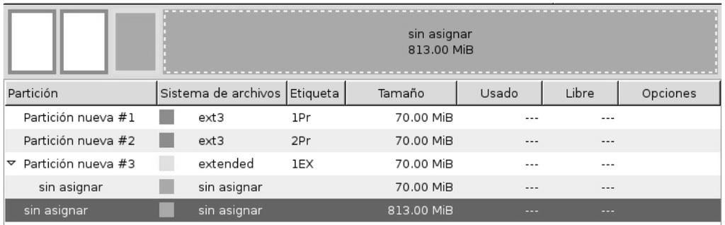

Intenta hacer otra partición que sea primaria, lógica y extendida. Completa las siguientes frases:

1. Si en un disco duro con 2 particiones primarias y una extendida creamos una partición primaria más obtenemos que...

Sí podemos crearla No podemos crearla

2. Si en un disco duro con 2 particiones primarias y una extendida creamos una partición lógica más fuera de la extendida obtenemos que...

Sí podemos crearla No podemos crearla

3. Si en un disco duro con 2 particiones primarias y una extendida creamos una partición lógica más dentro de la extendida obtenemos que...

Sí podemos crearla No podemos crearla

4. Si en un disco duro con 2 particiones primarias y una extendida creamos una partición extendida más obtenemos que...

Sí podemos crearla No podemos crearla

3. **Ejercicio 03**: mira el siguiente pantallazo y di cuántas particiones primarias, extendidas y lógicas puedes ver.

[figure not shown]

1. Primarias:

2. Extendidas:

3. Lógicas:

4. ¿Qué sistema de archivos utiliza la 2ª partición primaria?

5. ¿Qué sistema de archivos utiliza la 2ª partición lógica?

6. ¿Cuántas particiones primarias puedo hacer?

4. **Ejercicio 04**: responde a las siguientes preguntas.

1. ¿Cuál es el formato del sistema de archivos que utiliza Windows en la actualidad?

NTFS EXT4 FAT32

2. ¿Cuál es el tamaño máximo de archivo (en GB) para la partición FAT32?

3. ¿Guarda FAT32 permisos para distintos usuarios?

Sí No

4. ¿Guarda NTFS permisos para distintos usuarios?

Sí No

5. ¿Cuál es el formato del sistema de archivos que utiliza Linux en la actualidad?

NTFS EXT4 FAT32

6. ¿Para qué sirve la partición swap?

Es el área de intercambio Para la instalación, luego se borra

7. ¿Cuántas particiones primarias puedes hacer como máximo en una tabla msdos?

8. ¿Cuántas particiones extendidas puedes hacer como máximo?

9. Si tienes dos particiones primarias, ¿cuántas particiones primarias más puedes hacer?

10. Si tienes dos particiones primarias, ¿cuántas particiones extendidas puedes hacer?

11. Si tienes dos particiones primarias, ¿cuántas particiones lógicas puedes hacer sin crear antes una extendida?

12. Si tienes tres particiones primarias, ¿cuántas particiones extendidas puedes hacer?

13. Si tienes cuatro particiones primarias, ¿cuántas particiones extendidas puedes hacer?

14. ¿Cuántas particiones primarias puedes hacer dentro de la extendida?

15. ¿De dónde venía el límite clásico de 23 particiones lógicas?

De las letras de unidad de MS-DOS (de D: a Z:) Del tamaño del EBR Del número de entradas de la tabla del MBR

16. ¿Cuántas particiones extendidas puedes hacer dentro de una primaria?

## Particiones (II)

1. Fíjate en el siguiente esquema de particiones:

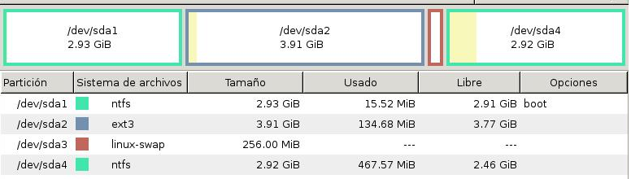

1. ¿A qué sistema operativo crees que pertenece la primera partición primaria?

Windows Linux

2. Fíjate en el siguiente esquema de particiones:

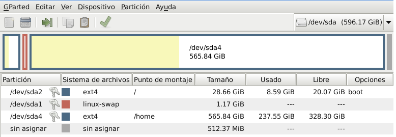

1. La partición de arranque es:

2. ¿Cuántas particiones lógicas tiene el disco duro?

3. Fíjate en el siguiente esquema de particiones:

[figure not shown]

1. Podemos crear:

Dos particiones lógicas más dentro de la extendida Dos particiones primarias más dentro de la extendida Una extendida más

4. Fíjate en el siguiente esquema de particiones:

[figure not shown]

1. Podemos crear:

Una partición primaria más Dos particiones primarias más dentro de la extendida Una extendida más

5. Fíjate en el siguiente esquema de particiones:

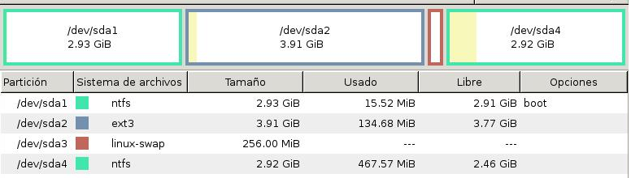

1. ¿Cuántas particiones primarias hay?

2. ¿Cuántas particiones lógicas hay?

3. ¿Cuántas particiones extendidas hay?

4. ¿Cuántos MiB de la 4ª partición están utilizados?

6. Fíjate en el siguiente esquema de particiones:

[figure not shown]

1. ¿Cuántas particiones extendidas hay?

7. Fíjate en el siguiente esquema de particiones:

[figure not shown]

1. ¿Cuántas particiones lógicas hay?

2. ¿Cuántos discos duros hay?

## Particiones (III)

1. MBR y GPT:

1. ¿Hasta qué tamaño de disco puede manejar una tabla MBR? (en TiB)

2. ¿Cuántas particiones admite por defecto una tabla GPT?

3. ¿Qué tabla de particiones necesita Windows 11?

GPT, porque Windows 11 exige UEFI msdos (MBR) Cualquiera de las dos

4. ¿Dónde guarda GPT la copia de seguridad de su cabecera y de su tabla?

Al final del disco En el MBR de protección En la partición ESP

5. ¿Con qué sistema de archivos se formatea la partición ESP?

FAT32 NTFS ext4

6. ¿Cómo se llama la partición de 16 MiB, sin sistema de archivos, que crea Windows en un disco GPT?

7. ¿Qué contiene la partición ESP?

Los cargadores de arranque de los sistemas operativos Los archivos del sistema operativo Windows La copia de seguridad de la tabla GPT

8. En un equipo con arranque dual Windows y Ubuntu en el mismo disco, ¿cuántas particiones ESP hay?

Una, la comparten los dos sistemas Dos, una para cada sistema Ninguna

9. Un equipo que arranca con BIOS y tabla MBR, ¿tiene partición ESP?

Sí No, el código de arranque está en el propio MBR

10. En un disco GPT con Windows y GNU/Linux (ESP, MSR, C:, D:, /, swap y /home), ¿cuántas particiones extendidas hacen falta?

2. Particiones lógicas y nombres:

1. ¿Qué es el EBR?

Un registro delante de cada partición lógica que indica dónde está esa partición y dónde está el siguiente EBR La copia de seguridad del MBR La partición donde se guardan los cargadores de arranque

2. En GNU/Linux, ¿en qué número empiezan las particiones lógicas?

3. ¿Cómo se llama en GNU/Linux la segunda partición del primer disco NVMe?

3. Velocidad:

1. En un disco duro mecánico, ¿qué particiones tienen mayor velocidad de transferencia?

Las del principio del disco (pistas exteriores) Las del final del disco (pistas interiores) Todas son igual de rápidas

2. ¿Y en un SSD?

Las del principio del disco Las del final del disco Todas son igual de rápidas